# Workshop_sf-geospatial_analysis

Nadine Daum, Oliver Pollex, Yun-Te Sung

October 25, 2024 | 22:21:03 | CEST

**Instructions for this tutorial:** This tutorial will (1.) provide the code for creating the Christmas market map as you saw in the presentation and (2.) lead you step-by-step - using the sf-package - to answer the question, in which Berlin district, most people have to “share” a Christmas market and where they should go instead. It will also show you the **closest Christmas markets from Hertie School**.

At the **end of the document, you will be asked to perform 3 tasks** to adapt the code. That will give you the opportunity to show what you have learned. In each code chunk all **sf-functions are explained** to optimize comprehensibility of the package. In this tutorial, we only cover sf-functions that are necessary to create the Berlin Christmas market map.

If you want to learn more about the package we recommend you the following material:

- For an overview and deep dive into the backend of the packages

  https://r-spatial.github.io/sf/articles/ https://r.geocompx.org/spatial-class.html#sf-classes
- Cheat sheet of functions

  https://github.com/rstudio/cheatsheets/blob/main/sf.pdf
- Case studies with step by step walkthroughs

  https://www.robwiederstein.org/2022/03/28/simple-features-tutorial-in-r-number-2/ https://www.jessesadler.com/post/gis-with-r-intro/

**About the sf-package:** The sf-package in R stands for **“simple features”** and is a powerful tool for handling **geo-spatial data**. It provides a standardized way to store and manipulate geographic vector data, integrating smoothly with the tidyverse suite of packages. With sf, you can easily **read, write, and analyze spatial data formats like shapefiles and GeoJSON**, which is **invaluable for creating maps and conducting spatial analyses**.

```r
# LOAD THE PACKAGES YOU WILL BE USING
library(sf)
library(dplyr)
library(ggplot2)
library(stringr)
library(rvest)
```

## 1. Creating the Berlin Christmas Market map

1. **Loading and Cleaning Berlin Districts Data**

*In this code chunk, we load the Berlin districts GeoJSON file, clean and standardize the district names, and visualize the districts using ggplot2 and sf.*

Explanation of sf-Package Functions:

**st_read()**: Reads spatial data from a file and returns it as an sf object, which contains both attribute data and geometry. **geom_sf()**: A ggplot2 function that adds a layer to the plot for handling sf objects, allowing for the visualization of spatial geometries.

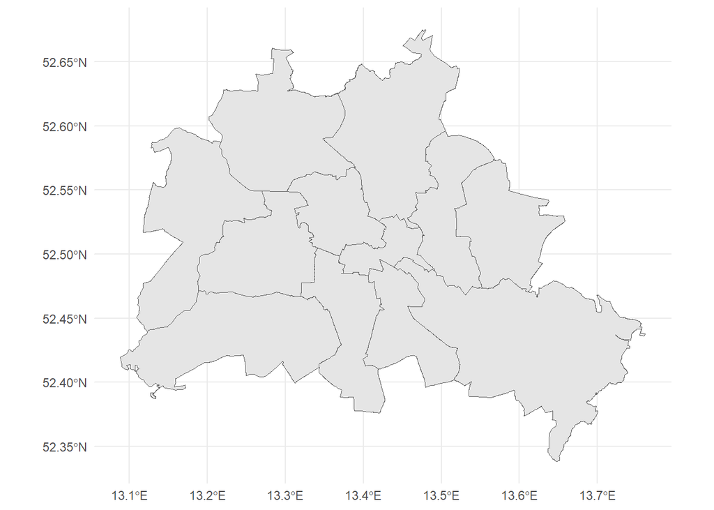

```r
# File path to the Berlin districts GeoJSON file
districts_file <- "data/bezirksgrenzen.geojson"  # Berlin districts GeoJSON path

# Function to clean and standardize district names
clean_district_names <- function(name) {
  name %>%
    str_replace_all("-", " ") %>%               # Replace dashes with spaces
    str_replace_all("[^\\w\\säöüÄÖÜß]", "") %>% # Remove any non-alphanumeric and non-German characters
    str_squish() %>%                            # Remove extra whitespace
    str_to_title()                              # Convert to title case
}

# Load the Berlin districts data and clean the district names
berlin_districts <- st_read(districts_file, quiet = TRUE) %>%          # Read the GeoJSON file into an sf object
  mutate(Gemeinde_name = clean_district_names(Gemeinde_name))  # Clean the district names using the custom function

# Plot the Berlin districts
ggplot() +
  geom_sf(data = berlin_districts) +   # Add the sf object as a layer to the plot
  theme_minimal()                      # Apply a minimal theme to the plot
```

2. **Loading and Visualizing Christmas Markets Data**

*In this code chunk, we load the Christmas markets data from an online GeoJSON source, read it into an sf object, and visualize the market locations using ggplot2. This demonstrates how to work with spatial data using the sf-package and how to plot it using ggplot2.*

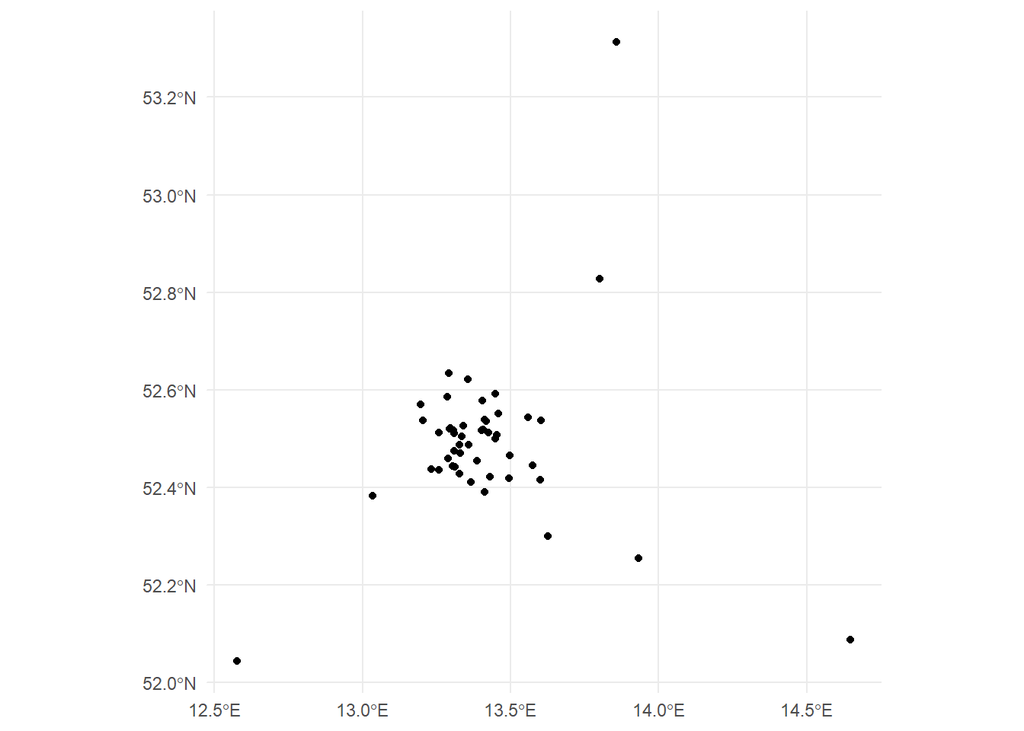

```r
# URL of the GeoJSON file containing Christmas markets data
christmas_markets_url <- "https://www.berlin.de/sen/web/service/maerkte-feste/weihnachtsmaerkte/index.php/index/all.geojson?q="

# Read the GeoJSON data into an sf object
christmas_markets <- st_read(christmas_markets_url, quiet = TRUE)
# st_read(): Reads spatial data files into sf objects, supporting various formats like GeoJSON, Shapefiles, etc.

# Plot the Christmas markets using ggplot2
ggplot() +
  geom_sf(data = christmas_markets) +  # geom_sf(): Adds spatial data from an sf object to the ggplot
  theme_minimal()                      # Apply a minimal theme to the plot
```

3. **Aligning Coordinate Reference Systems and Plotting Christmas Markets**

*In this code chunk, we align the Coordinate Reference Systems (CRS) of the Christmas markets and Berlin districts data to ensure they match. We then find the intersection of the two datasets to obtain only the Christmas markets within Berlin, calculate the centroids of the districts for labeling, and finally plot the Berlin districts and Christmas markets on a map.*

Explanation of sf-package Functions:

**st_crs()**: Retrieves or sets the Coordinate Reference System of an sf object. Aligning CRS is crucial for spatial operations to ensure that layers align correctly on a map.

**st_intersection()**: Computes the geometric intersection of two sf objects, returning the overlapping spatial features. This function is used to find common areas or features between datasets.

**st_centroid()**: Calculates the centroid (geometric center point) of spatial features within an sf object. Centroids are useful for labeling or summarizing spatial areas.

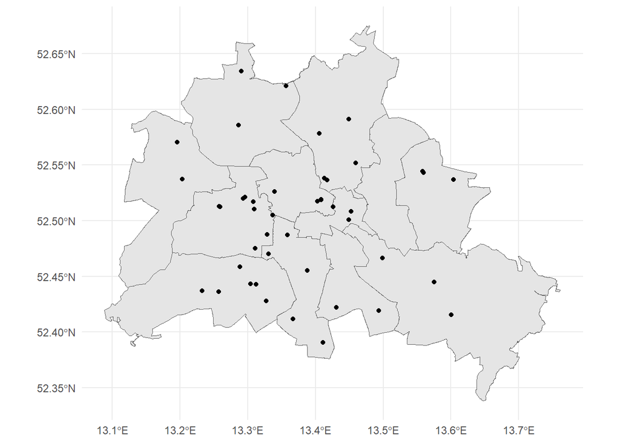

```r
# Set the CRS of the Christmas markets to match that of the Berlin districts
st_crs(christmas_markets) <- st_crs(berlin_districts)
# st_crs(): Gets or sets the Coordinate Reference System of an sf object
# Here, we assign the CRS of 'berlin_districts' to 'christmas_markets' to ensure they are the same

# Find the intersection of Christmas markets and Berlin districts to get markets within Berlin
christmas_markets_berlin <- st_intersection(christmas_markets, berlin_districts)
# st_intersection(): Computes the geometric intersection of two sf objects
# It returns spatial features that are common to both input datasets

# Calculate the centroids of each Berlin district for labeling purposes
berlin_districts_centroids <- st_centroid(berlin_districts) %>%  # Compute the geometric centers
  mutate(
    split_name = str_wrap(Gemeinde_name, width = 10)  # Wrap district names into lines of 10 characters
  )
# st_centroid(): Calculates the centroid (geometric center) of spatial features
# The 'mutate()' function adds a new column 'split_name' for nicely formatted district names

# Plot the Berlin districts and the Christmas markets within them
ggplot() +
  geom_sf(data = berlin_districts) +                # Plot the Berlin districts polygons
  geom_sf(data = christmas_markets_berlin) +        # Add the Christmas markets points to the plot
  theme_minimal()
```

```r
# geom_sf(): A ggplot2 function that adds a layer to the plot for sf objects
# It automatically handles the geometry and projection of the spatial data
```

4. **Finalizing and Styling the Map Visualization**

*In this code chunk, we create a detailed and styled map of Berlin showing the districts, Christmas markets, and district names. We customize the appearance of the map using various ggplot2 layers and functions, integrating spatial data handling from the sf-package.*

Explanation of sf-package functions:

**st_coordinates()**: Extracts the numeric coordinates of geometries from an sf object. It returns a matrix of coordinates, which can be used for plotting or analysis.

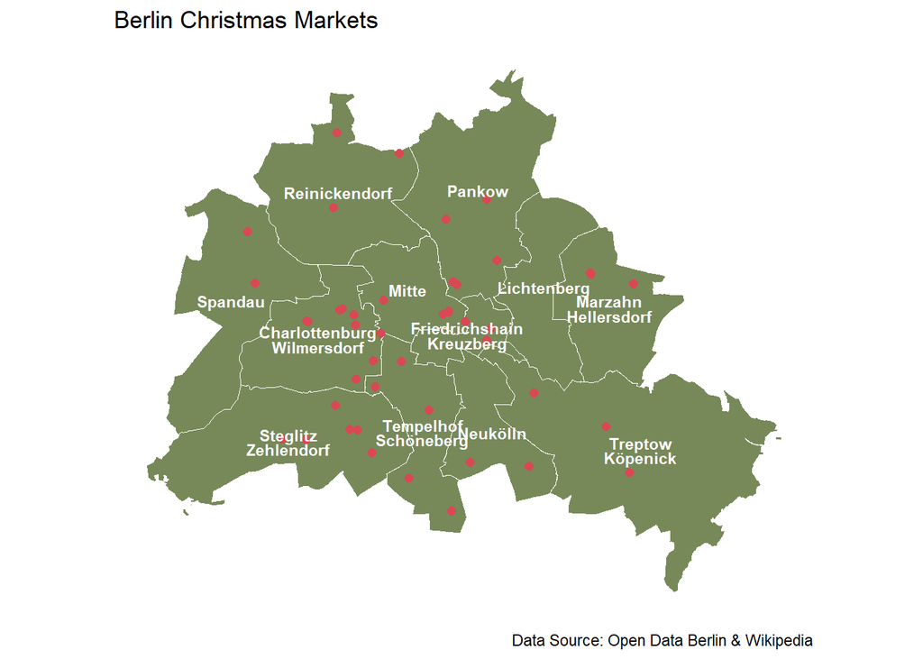

```r
ggplot(data = berlin_districts) +
  # Plot Berlin districts with specified fill and border color
  geom_sf(fill = 'darkolivegreen', color = "white", size = 0.4, alpha = 0.8) +  # District borders in white
  # geom_sf(): Plots spatial data from an sf object; here, it draws the polygons of the districts

  # Plot each Christmas market as a red point
  geom_sf(
    data = christmas_markets_berlin,                    # Use the Christmas markets data within Berlin
    aes(geometry = geometry),                           # Aesthetic mapping for geometry
    color = "#D94854",                                  # Outline color of the points
    size = 2,                                           # Size of the points
    shape = 21,                                         # Shape code for points with fill and outline
    fill = "#D94854"                                    # Fill color of the points
  ) +
  # geom_sf(): Plots spatial data from an sf object; here, it plots the Christmas market locations as points

  # Add district names at centroids
  geom_text(
    data = berlin_districts_centroids,                  # Use the centroids of the districts for label placement
    aes(
      x = st_coordinates(geometry)[, 1],                # Extract x-coordinate of centroids
      y = st_coordinates(geometry)[, 2],                # Extract y-coordinate of centroids
      label = split_name                                # Text labels (district names) to display
    ),
    size = 3,                                           # Text size
    color = "white",                                    # Text color
    fontface = "bold",                                  # Make text bold
    lineheight = 0.8                                    # Adjust line height for wrapped text
  ) +
  # st_coordinates(): Extracts coordinates from sf objects; used here to get x and y positions for labels
  # geom_text(): Adds text labels to the plot at specified positions

  # Add title and caption to the plot
  labs(
    title = "Berlin Christmas Markets",                 # Title of the map
    caption = "Data Source: Open Data Berlin & Wikipedia"  # Caption with data sources
  ) +
  # labs(): Adds labels like title and caption to the plot

  # Apply minimal theme and remove axis elements
  theme_minimal() +
  theme(
    axis.title = element_blank(),                       # Remove axis titles
    axis.text = element_blank(),                        # Remove axis text
    axis.ticks = element_blank(),                       # Remove axis ticks
    panel.grid = element_blank()                        # Remove background grid
  )
```

## 2. Enriching the Berlin Christmas market map with population density and proximity to Hertie School.

If you were the major of Berlin, you might ask yourself where to open a new, shiny Christmas market. Your intuition might be that a new Christmas market makes sense in a district where there are the fewest markets relative to the population size, assuming that markets there are most crowded.

What is your intuition? Which district has fewest markets in relation to population size?

Let’s find out with the help of the sf-package. At the bottom of the code, there are 3 tasks for you to complete, which will give you the opportunity to apply what you have learned.

1. **Scraping Population Data and Joining with Spatial Data**

*We know already where the markets are located. We now need to count the markets in each district and find out how many people live in each district. In this code chunk, we scrape population data for Berlin districts from a Wikipedia page, clean and preprocess the data, and then perform a spatial join with the Christmas markets data to count the number of markets per district.*

Explanation of sf-Package functions:

**st_join()**: Performs a spatial join between two sf objects, combining their attributes based on spatial relationships (e.g., intersections, containment).

**st_intersects()**: A spatial predicate function used to determine if geometries intersect; used here to specify the type of spatial relationship for the join.

**st_drop_geometry()**: Removes the geometry column from an sf object, returning a regular data frame without spatial attributes.

```r
# URL of the Wikipedia page containing population data for Berlin districts
population_url <- "https://de.wikipedia.org/wiki/Bevölkerung_von_Berlin"  # Wikipedia page with population data

# Scrape population data from Wikipedia
population_data <- read_html(population_url) %>%    # Read the HTML content of the Wikipedia page
  html_node("table.wikitable") %>%                  # Select the first table with class 'wikitable'
  html_table() %>%                                  # Convert the HTML table to a data frame
  select(Bezirk = 1, Bevölkerung = 2) %>%           # Select columns: District (Bezirk) and Population (Bevölkerung)
  mutate(
    # Clean the district names
    Bezirk = str_squish(Bezirk) %>%                 # Remove leading/trailing whitespace and reduce multiple spaces
      str_replace_all("-", " ") %>%                 # Replace hyphens with spaces
      str_replace_all("\\s+", " ") %>%              # Replace multiple spaces with a single space
      str_to_title(),                               # Convert district names to title case

    # Remove duplicates within the district names
    Bezirk = sapply(Bezirk, function(x) {           # Apply a function to each district name
      words <- unlist(str_split(x, " "))            # Split the name into individual words
      unique_words <- unique(words)                 # Remove duplicate words
      paste(unique_words, collapse = " ")           # Reconstruct the name without duplicates
    }),

    # Clean the population numbers
    Bevölkerung = as.numeric(gsub("\\.", "", Bevölkerung))  # Remove dots (thousands separator) and convert to numeric
  ) %>%
  filter(!is.na(Bevölkerung))                       # Filter out any rows with missing population data

# Join Christmas markets with district data and count the number of markets per district
markets_per_district <- st_join(
  christmas_markets_berlin,                         # Spatial data of Christmas markets within Berlin
  berlin_districts,                                 # Spatial data of Berlin districts
  join = st_intersects                              # Join where geometries intersect
) %>%
  st_drop_geometry() %>%                            # Remove geometry columns to simplify the data frame
  group_by(Gemeinde_name.y) %>%                     # Group by the district name from the districts data
  summarise(Christmas_Markets = n()) %>%            # Count the number of markets per district
  mutate(Gemeinde_name.y = clean_district_names(Gemeinde_name.y))  # Clean the district names using a custom function
```

2. **Merging Data and Calculating Market Density**

*In this code chunk, we merge the Christmas markets data with the population data to calculate the market density (number of markets per 1,000 residents) for each district. We then join this enriched data back to the spatial data of Berlin districts to prepare for visualization.*

```r
# Merge the markets and population data
final_table <- markets_per_district %>%                           # Start with the markets per district data
  left_join(population_data, by = c("Gemeinde_name.y" = "Bezirk")) %>%  # Join population data by matching district names
  mutate(
    Market_Density_per_1000_residents = (Christmas_Markets / Bevölkerung) * 1000  # Calculate markets per 1,000 residents
  ) %>%
  select(
    District = Gemeinde_name.y,                  # Rename 'Gemeinde_name.y' to 'District'
    Population = Bevölkerung,                    # Rename 'Bevölkerung' to 'Population'
    Christmas_Markets,                           # Keep the 'Christmas_Markets' column
    Market_Density_per_1000_residents            # Keep the calculated density
  ) %>%
  arrange(desc(Market_Density_per_1000_residents))  # Sort the data by market density in descending order

# Join the density data back to the berlin_districts for visualization
berlin_districts <- berlin_districts %>%
  mutate(District = clean_district_names(Gemeinde_name)) %>%      # Clean and standardize district names
  left_join(final_table, by = c("District" = "District"))         # Join the final table data by 'District' name
```

3. **Calculating Distances to the Hertie School**

*In this code chunk, we manually set the coordinates for the Hertie School and calculate the distances from the school to each Christmas market in Berlin. We then create a table of the five closest markets and identify them for further analysis or visualization.*

Explanation of sf-Package functions:

**st_as_sf():** Converts a data frame or other object into an sf object, integrating spatial geometry with attribute data.

**st_sfc()**: Creates a simple feature geometry list column, which can store multiple geometries (e.g., points, lines).

**st_point()**: Constructs a POINT geometry from given coordinates.

**st_distance()**: Calculates pairwise distances between geometries in two sf objects, returning a distance matrix.

```r
# Manually set coordinates for Hertie School (approximate coordinates for Friedrichstraße 180)
hertie_coords <- c(13.388860, 52.520008)  # Longitude and Latitude for Hertie School

# Create an sf point for Hertie School
hertie_point <- st_as_sf(
  data.frame(
    name = "Hertie",                              # Assign the name "Hertie" to the point
    geometry = st_sfc(st_point(hertie_coords)),   # Create a simple feature geometry column with the coordinates
    stringsAsFactors = FALSE                      # Do not convert strings to factors
  ),
  crs = st_crs(berlin_districts)                  # Set the Coordinate Reference System to match berlin_districts
)

# Distance calculation between Hertie School and each Christmas market
distances <- st_distance(hertie_point, christmas_markets_berlin) %>% as.numeric()
# st_distance(): Computes pairwise distances between geometries in two sf objects

# Create a table with distances and market information
distance_table <- christmas_markets_berlin %>%
  st_drop_geometry() %>%                           # Remove geometry column to simplify data frame
  mutate(Distance_to_Hertie_m = distances) %>%     # Add distances to the data frame
  arrange(Distance_to_Hertie_m) %>%                # Sort markets by distance to Hertie School
  slice(1:5)                                       # Select the 5 closest markets
# st_drop_geometry(): Removes the geometry column from an sf object, returning a data frame

# Display the optimized distance table for readability
optimized_distance_table <- distance_table %>%
  select(Christmas_Market = title, Distance_to_Hertie_m)  # Select and rename columns for clarity

# Mark the closest five Christmas markets with a distinct color
closest_markets <- christmas_markets_berlin[which(christmas_markets_berlin$id %in% distance_table$id), ]
```

4. **Plotting Berlin Districts with Market Density and Proximity to Hertie School**

*In this code chunk, we generate a detailed map of Berlin districts, coloring them based on the density of Christmas markets per 1,000 residents. We plot all Christmas markets, highlight the ones closest to the Hertie School, mark the location of the Hertie School, and add labels for districts and the school.*

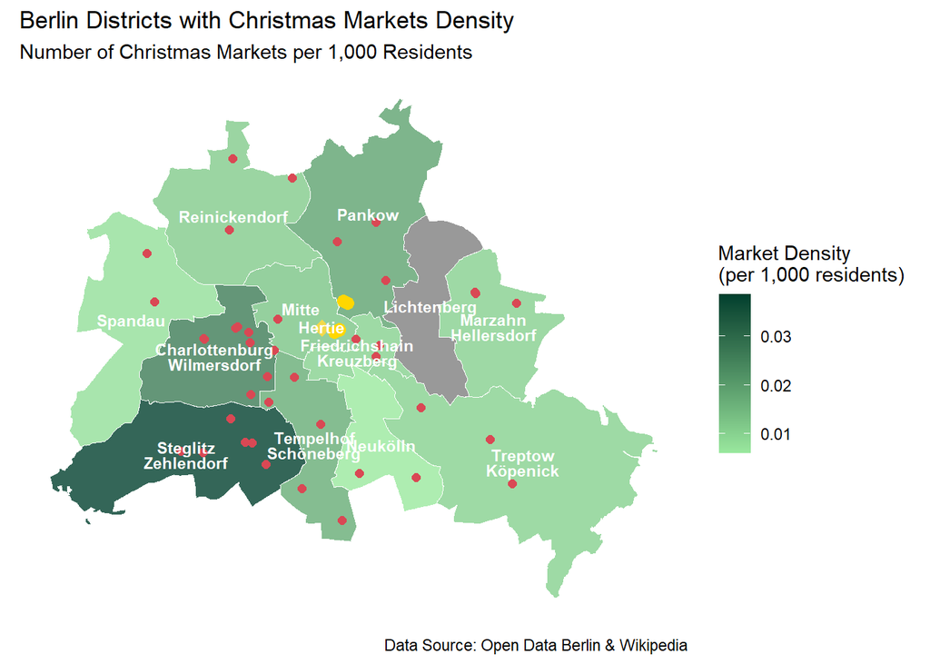

```r
# Plot the Berlin districts colored by market density and include points and names
ggplot(data = berlin_districts) +
  # Plot districts with fill based on market density
  geom_sf(
    aes(fill = Market_Density_per_1000_residents),  # Color fill based on market density
    color = "white",        # District borders in white
    size = 0.4,             # Border line width
    alpha = 0.8             # Transparency of district fill
  ) +
  # geom_sf(): Plots spatial data from an sf object; handles geometries

  # Apply a green gradient scale for density
  scale_fill_gradient(
    low = "#9AE89E",        # Low end of gradient color
    high = "#01402E",       # High end of gradient color
    name = "Market Density\n(per 1,000 residents)"  # Legend title
  ) +

  # Plot each Christmas market as a red point
  geom_sf(
    data = christmas_markets_berlin,                # Data for Christmas markets
    aes(geometry = geometry),                       # Geometry mapping
    color = "#D94854",                              # Point outline color
    size = 2,                                       # Point size
    shape = 21,                                     # Point shape allowing fill and color
    fill = "#D94854"                                # Point fill color
  ) +

  # Plot the closest Christmas markets as gold points
  geom_sf(
    data = closest_markets,                         # Data for closest markets
    aes(geometry = geometry),                       # Geometry mapping
    color = "gold",                                 # Point outline color
    size = 3,                                       # Larger size to stand out
    shape = 21,                                     # Shape allowing fill and color
    fill = "gold"                                   # Point fill color
  ) +

  # Plot the Hertie School point in yellow
  geom_sf(
    data = hertie_point,                            # Data for Hertie School location
    aes(geometry = geometry),                       # Geometry mapping
    color = "#F2D94A",                              # Point outline color
    size = 3,                                       # Point size
    shape = 23,                                     # Diamond shape
    fill = "#F2D94A"                                # Point fill color
  ) +

  # Add label for the Hertie School
  geom_text(
    data = hertie_point,                            # Data for labeling
    aes(
      x = st_coordinates(geometry)[1],              # X-coordinate of Hertie
      y = st_coordinates(geometry)[2] + 0.001,      # Y-coordinate adjusted upward
      label = name                                  # Label text
    ),
    size = 3,                                       # Text size
    color = "white",                                # Text color
    fontface = "bold"                               # Bold text
  ) +

  # Add district names at centroids
  geom_text(
    data = berlin_districts_centroids,              # Data for district centroids
    aes(
      x = st_coordinates(geometry)[, 1],            # X-coordinates of centroids
      y = st_coordinates(geometry)[, 2],            # Y-coordinates of centroids
      label = split_name                            # District names
    ),
    size = 3,                                       # Text size
    color = "white",                                # Text color
    fontface = "bold",                              # Bold text
    lineheight = 0.8                                # Adjust line spacing for wrapped text
  ) +

  # Add title, subtitle, and caption to the plot
  labs(
    title = "Berlin Districts with Christmas Markets Density",        # Plot title
    subtitle = "Number of Christmas Markets per 1,000 Residents",     # Plot subtitle
    caption = "Data Source: Open Data Berlin & Wikipedia"             # Data source caption
  ) +

  # Apply minimal theme and remove axis elements
  theme_minimal() +
  theme(
    axis.title = element_blank(),                   # Remove axis titles
    axis.text = element_blank(),                    # Remove axis text
    axis.ticks = element_blank(),                   # Remove axis ticks
    panel.grid = element_blank()                    # Remove background grid lines
  )
```

Our map shows that the christmas market density per 1000 residents is lowest in Lichtenberg (where there are 0 markets, if we believe the data we found) and Neukölln. Additionally, we can see that both districts have no neighboring districts with a very high density. So as mayor of Berlin we might decide to open our new market in either Neukölln or Lichtenberg. Would you take the same decision?

**To learn how to use the sf-package here are three tasks:**

1. The mayor does not really like the green color gradient of your map. Change it to blue.
2. The mayor decides that students from Hertie can walk further than just to the 5 markets colored in gold. Mark the 10 closest markets to Hertie in gold.
3. A friend of yours went to a market in Brandenburg and was amazed by how beautiful Berlin’s surroundings are. Now you also want to join and decide to include Brandenburg’s Christmas markets from the data set on your map. Don’t worry that they will be free floating on the map.